# Election Analysis for 2016, 2020

Taha Juzer Husain

14/03/2021

# Introduction

In this report, we analyze results of elections in Ireland in 2016 and 2020. We represent different graphics to understand how parties performed in the two years and which party gained or lost more votes over time.

## Vote Counts per party for 2016 and 2020

Figure 1 represents the vote counts for different parties for year 2016 and 2020. The plot uses grouped bars to represent each party for different years. It also presents the change in votes from 2016 and 2020. According to the figure, Independent party’s vote has increased over the years, while some other parties faced reduction in vote over the time.

### Design Decisions

- Grouped bar plots are used to show vote count for different years
- color codes are used for different years
- The plot uses *Okabi and Ito’s* palette, so the colors could be distinct for user’s with CVD.
- *Tufte lines* are used so users could connect each bar with the y axis.

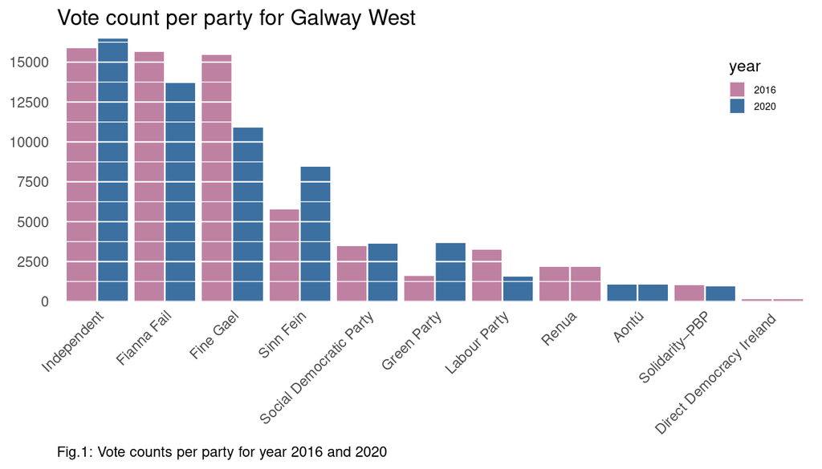

## Vote count plot for CVD users

Below figure represents the grouped bar graphs for CVD vision. The plot uses CVD friendly colors which help CVD users to see the colors distinctly.

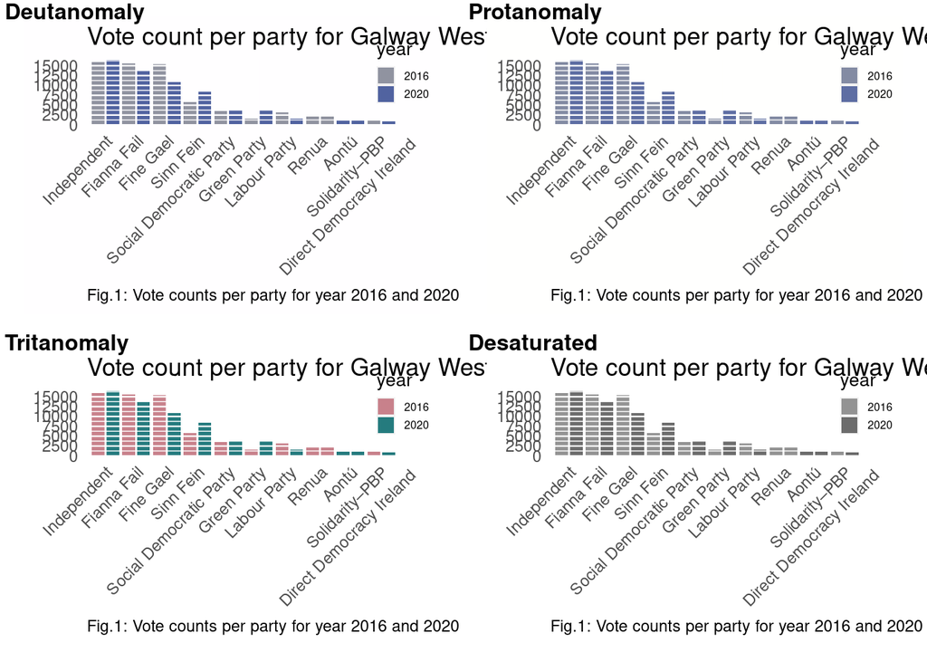

## Change in vote from 2016 - 2020

### Design Decisions

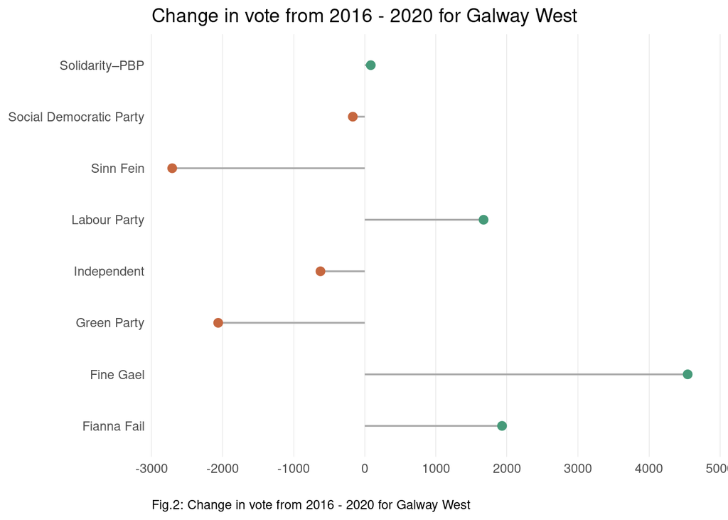

## Comparing performance for parties at national and Galway region for 2016

The data for performance at national level was obtained from www.tcd.ie/Political_Science website.

Figure 3 represents comparison between the performance of a party at national level and regional level for 2016. The length of line between the two points represent the difference between the percentage of the party to the total votes for regional and national level. If the line between points is small it shows there was a small difference between percentages of regional and national level. Some parties do not have records for regional and this causes a single point representing percentage of national level.

### Design Decisions

- A dot plot is used for combining and compare different party’s performance at regional and national level.
- Colors are CVD user friendly.
- Different colors are used to represent different regions.

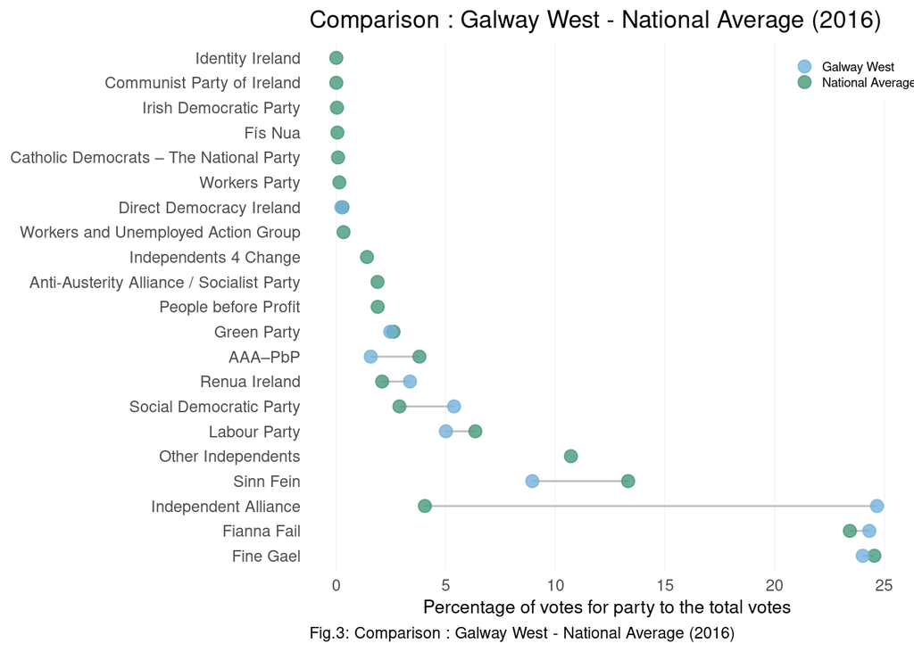

## Comparing performance for parties at national and Galway region for 2020

Figure 4 represents comparison between the performance of a party at national level and regional level for the year 2020. The points represent percentage of vote for the party from the total votes. The length of line between the two points represent the difference between regional and national level.

### Design Decisions

- A dot plot is used to show the difference between the percentages.
- Length of line between the points could give an idea of the difference
- The two colors represent region and national average.

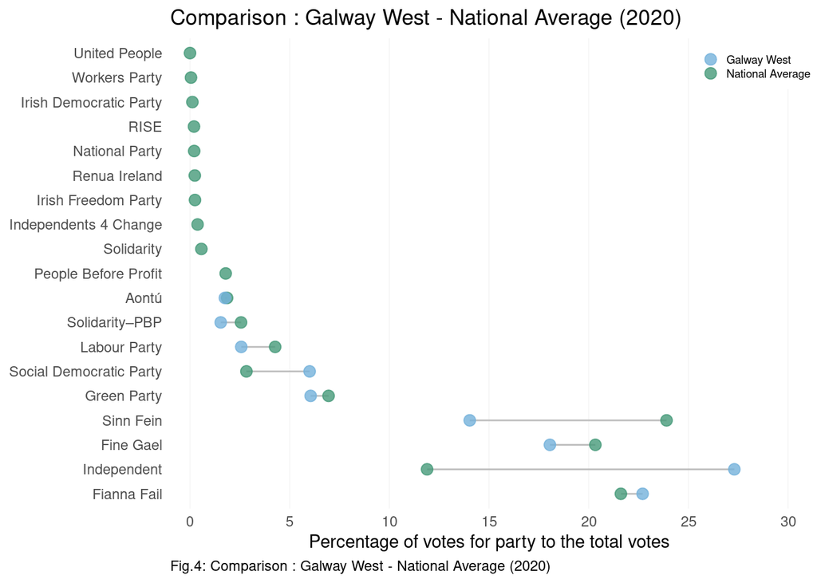

## Significant candidate change from 2016 to 2020

### Design Decisions

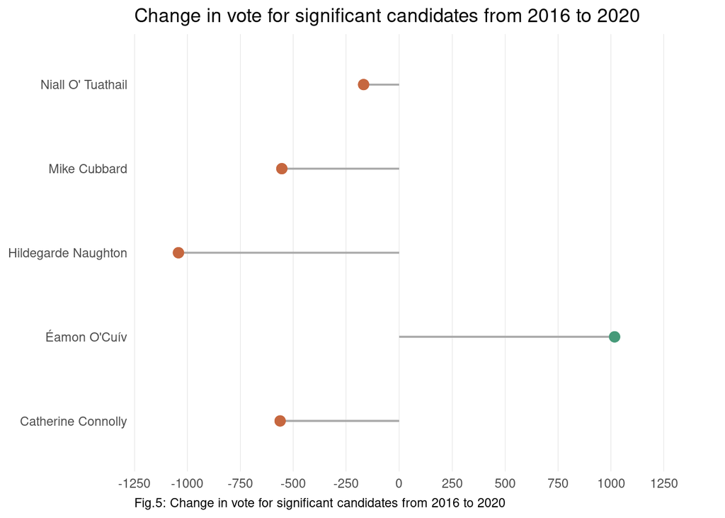

## Refrences

- Lecture Notes
- GGPLOT Notes
- www.tcd.ie/Political_Science

```r
# loading libraries and reading data
library(readxl)

GalwayWest_2020 <- read_excel("GalwayWest-2020.xlsx", col_names = T, skip = 1)
GalwayWest_2020$Party <- GalwayWest_2020$...2
GalwayWest_2020 <- GalwayWest_2020[-c(2)]

GalwayWest_2016 <- read.csv("2016-04-28_general-election-count-details-galway-west-csv_en.csv")
## data wrangling is performed and generated new data frame which will be required for the plot in the future
## data from different year are manipulated differently and merged afterwards

library(tidyverse)
votes_per_party_2016 = GalwayWest_2016 %>% filter(Count.Number == 1) %>%
  group_by(Party) %>% mutate(votes_per_party = sum(Total.Votes), year = "2016")  %>% select(Party, votes_per_party, year)
votes_per_party_2016 <- unique(votes_per_party_2016[c("Party", "votes_per_party", "year")])

votes_per_party_2020 = GalwayWest_2020 %>% filter(is.na(GalwayWest_2020$Party) != T) %>% group_by(Party) %>% mutate(votes_per_party = sum(`Count 1`), year = "2020") %>% select(Party, votes_per_party, year)
votes_per_party_2020 <- unique(votes_per_party_2020[c("Party", "votes_per_party", "year")])

all_votes = rbind(votes_per_party_2016, votes_per_party_2020)

## changing party names to make them consistent with both years data
all_votes$Party[c(1, 19)] = "Solidarity–PBP"
all_votes$Party[c(3, 11)] = "Fianna Fail"
all_votes$Party[c(4, 14)] = "Fine Gael"
all_votes$Party[c(6, 12)] = "Independent"
all_votes$Party[c(9, 15)] = "Social Democratic Party"
all_votes$Party[c(10, 13)] = "Sinn Fein"

## using color palette from Okabi and Ito's palette for CVD users
library(colorspace)
cbPalette <- desaturate(c("#999999", "#E69F00", "#56B4E9", "#009E73", "#F0E442", "#0072B2", "#D55E00", "#CC79A7"), 0.25)

## creating a grouped bar plot using ggplot2
plot1 = ggplot(all_votes, (aes(x= reorder(Party, -votes_per_party), y=votes_per_party, fill=year))) +
 geom_col(position="dodge") +
  scale_y_continuous(
    breaks = seq(0, 17500, 2500),
    expand = c(0, 0)) +
scale_fill_manual(values = cbPalette[c(8,6)]) +
  labs(caption = "Fig.1: Vote counts per party for year 2016 and 2020")+
  ggtitle("Vote count per party for Galway West") +
    theme(
      axis.line.y = element_blank(),
      axis.ticks.y = element_blank(),
      axis.line.x = element_blank(),
      axis.ticks.x = element_blank(),
      axis.title.x = element_blank(),
      axis.title.y = element_blank(),
      axis.title = element_text(size=9),

      panel.background=element_blank(),
      axis.text.x = element_text(angle = 45, vjust = 1, hjust = 1),
      panel.grid.major.y = element_line(size = 0.4, linetype = 'solid',colour = "white"),
      panel.ontop = TRUE,
      legend.position= c(0.92, 0.82),
      legend.text = element_text(size = 6), # legend text  was a little large
      legend.key.size = unit(0.7, "lines"), # legend key size was a little large
      legend.title = element_text(size =10),
        plot.caption = element_text(hjust = 0))# legend title  was a little large)
plot1
## plotting above plot for CVD users
library(colorblindr)
cvd_grid(plot1)
## creating a data frame with the difference in votes for parties from 2016 to 2020
## taking unique parties and taking difference between the votes
dif = data.frame()
party_unique = unique(all_votes$Party)
for (i in party_unique){
  temp = all_votes %>% filter(Party == i) %>% arrange(year) %>% mutate(differ = votes_per_party[1] - votes_per_party[2], Part = i, change = ifelse(differ > 0, TRUE, FALSE)) %>% select(differ, Part, change)
dif = rbind.data.frame(dif, temp)
}
dif = unique(dif[c("Part", "differ", "change")])
dif = filter(dif, !is.na(differ))
## dot plot to show difference between the votes from 2016 to 2020
theme_set(theme_classic())
ggplot(dif, aes(x=differ, y=Part, colour = change)) +
        geom_segment(aes(x = 0, y = Part, xend = differ, yend = Part), size = 0.6, color = "darkgrey") +
        geom_point(size =2.5) +

  ggtitle("Change in vote from 2016 - 2020 for Galway West")+
  labs(caption = "Fig.2: Change in vote from 2016 - 2020 for Galway West")+
   scale_colour_manual(values= cbPalette[c(7,4)], name = "") +

  scale_x_continuous(limits = c(-3000, 5000),
                     expand = c(0, 0),
                     breaks = seq(-3000,5000, by = 1000),
                     name = "") +
  theme(axis.line.y = element_blank(),
        panel.grid.major.x = element_line(size=0.04, colour = "grey50"),
    axis.line.x = element_blank(),
    axis.ticks.y = element_blank(),
    axis.ticks.x = element_blank(),
    axis.title.y = element_blank(),
    legend.position = "None",
    axis.title.x = element_text(size = 9),
     plot.caption = element_text(hjust = 0))
## reading data for national and creating data frames for different years
## data is modified and percentage is calculated for each party and merged the data frames

results_2016 <- read_excel("results-2016.xlsx")
results_2020 <- read_excel("results-2020.xlsx")

national_2016 <- results_2016 %>% rename(Party = `2016 election result`) %>% mutate(votes_percentage = round((Votes / sum(Votes)) * 100, 2), election_type = "National Average") %>% select(Party, votes_percentage, election_type)

votes_per_party_2016$votes_percentage = round(votes_per_party_2016$votes_per_party / sum(votes_per_party_2016$votes_per_party) * 100, 2)
votes_per_party_2016$election_type = "Galway West"

galway_2016 = votes_per_party_2016 %>% select(Party, votes_percentage, election_type)

comparision_2016 = rbind.data.frame(national_2016, galway_2016)

## party names are made consistent for the plot

comparision_2016$Party[c(1, 25)] = "Fine Gael"
comparision_2016$Party[c(2, 24)] = "Fianna Fail"
comparision_2016$Party[c(3, 31)] = "Sinn Fein"
comparision_2016$Party[c(4, 28)] = "Labour Party"
comparision_2016$Party[c(5, 22)] = "AAA–PbP"
comparision_2016$Party[c(12, 23)] = "Direct Democracy Ireland"
comparision_2016$Party[c(9, 26)] = "Green Party"
comparision_2016$Party[c(19, 27)] = "Independent Alliance"
comparision_2016$Party[c(19, 27)] = "Independent Alliance"
comparision_2016$Party[c(4, 28)] = "Labour Party"
comparision_2016$Party[c(10, 29)] = "Renua Ireland"
comparision_2016$Party[c(8, 30)] = "Social Democratic Party"
```

```r
national_2020 <- results_2020 %>% rename(Party = `2020 election result`) %>% mutate(votes_percentage = round((Votes / sum(Votes)) * 100, 2), election_type = "National Average") %>% select(Party, votes_percentage, election_type)

votes_per_party_2020$votes_percentage = round(votes_per_party_2020$votes_per_party / sum(votes_per_party_2020$votes_per_party) * 100, 2)
votes_per_party_2020$election_type = "Galway West"

galway_2020 = votes_per_party_2020 %>% select(Party, votes_percentage, election_type)

comparision_2020 = rbind.data.frame(national_2020, galway_2020)

comparision_2020$Party[c(1, 22)] = "Sinn Fein"
comparision_2020$Party[c(3, 23)] = "Fine Gael"
comparision_2020$Party[c(2, 20)] = "Fianna Fail"

comparision_2020$Party[c(5, 26)] = "Labour Party"
comparision_2020$Party[c(7, 28)] = "Solidarity–PBP"

comparision_2020$Party[c(4, 25)] = "Green Party"
comparision_2020$Party[c(19, 21)] = "Independent"
comparision_2020$Party[c(5, 26)] = "Labour Party"
comparision_2020$Party[c(6, 24)] = "Social Democratic Party"

## creating dot plot for comparing 2016 parties at national and Galway region

ggplot(comparision_2016, aes(x=votes_percentage, y =reorder(Party, -votes_percentage))) +
  geom_line(aes(group = Party), colour = "grey", size=0.5) +
   geom_point(size = 3, aes(colour=election_type), alpha = 0.8) +
   scale_colour_manual(values= cbPalette[c(3,4)], name = "")+
    ggtitle("Comparison : Galway West - National Average (2016)") +
  xlab("Percentage of votes for party to the total votes") +
  labs(caption = "Fig.3: Comparison : Galway West - National Average (2016)")+
  theme(axis.title.y = element_blank(),
    panel.grid.major.x = element_line(size=0.02, colour = "grey50"),
    panel.grid.minor.x = element_blank(),
    panel.grid.major.y = element_blank(),
    axis.line.y = element_blank(),
    axis.line.x = element_blank(),
    axis.ticks.y = element_blank(),
    axis.ticks.x = element_blank(),
    axis.title = element_text(size = 10),
      legend.position= c(0.92, 0.95),
      legend.text = element_text(size = 7), # legend text  was a little large
      legend.key.size = unit(0.6, "lines"),
      legend.title = element_blank(),
     plot.caption = element_text(hjust = 0))# legend keys were a little large

## creating dot plot for comparing 2020 parties at national and Galway region

ggplot(comparision_2020, aes(x=votes_percentage, y =reorder(Party, -votes_percentage))) +
    geom_line(aes(group = Party), colour = "grey", size=0.5) +
   geom_point(size = 3, aes(colour=election_type), alpha = 0.8) +
   scale_colour_manual(values=  cbPalette[c(3,4)], name = "")+
  scale_x_continuous(limits = c(0, 30),
                     expand = c(0, 1),
                     breaks = seq(0,30, by = 5)) +

  ggtitle("Comparison : Galway West - National Average (2020)") +
  xlab("Percentage of votes for party to the total votes") +
  labs(caption = "Fig.4: Comparison : Galway West - National Average (2020)")+
  theme(axis.title.y = element_blank(),
    panel.grid.major.x = element_line(size=0.02, colour = "grey50"), # using light grey gridlines for better readabilty
      panel.grid.minor.x = element_blank(),
    panel.grid.major.y = element_blank(),
    axis.line.y = element_blank(),
    axis.line.x = element_blank(),
    axis.ticks.y = element_blank(),
    axis.ticks.x = element_blank(),
      legend.position= c(0.92, 0.95),
      legend.text = element_text(size = 7), # legend text  was a little large
      legend.key.size = unit(0.6, "lines"),
      legend.title = element_blank(),# legend keys were a little large
     plot.caption = element_text(hjust = 0))

## creating a data frame with the difference in votes for significant candidates from 2016 to 2020
## taking candidates who are consistent in 2016 and 2020

## filtering data based on count 1 and cleaning the data for further use.
g_2016 = GalwayWest_2016 %>% filter(Count.Number == 1) %>% mutate("Candidate" = paste0(Candidate.First.Name, " ", Candidate.surname), "Year" = 2016, "Votes" = Total.Votes) %>% select(Votes, Party, Candidate, Year)

g_2020 = GalwayWest_2020 %>% filter(is.na(Candidate) == F)  %>% mutate("Year" = 2020, "Votes" = `Count 1`) %>% select(Votes, Party, Candidate, Year)

significant_cand = rbind.data.frame(g_2016, g_2020)

significant_cand$Candidate[c(3, 21)] = "Éamon O'Cuív"
significant_cand$Candidate[c(8, 26)] = "Sean Kyne"
significant_cand$Candidate[c(15, 24)] = "Catherine Connolly"
significant_cand$Candidate[c(19, 27)] = "Niall O' Tuathail"

candidate_list = c("Catherine Connolly", "Éamon O'Cuív", "Hildegarde Naughton", "Mike Cubbard", "Niall O' Tuathail")

sig = data.frame()

for (i in candidate_list){
temp = significant_cand %>% filter(Candidate == i) %>% arrange(Year) %>% mutate(differ = Votes[1] - Votes[2], Candidate = i, change = ifelse(differ > 0, TRUE, FALSE)) %>% select(differ, Candidate, change)
sig = rbind.data.frame(sig, temp)

}

## creating a dot plot for change in vote using the difference between votes
ggplot(sig, aes(x=differ, y=Candidate, colour = change)) +
        geom_segment(aes(x = 0, y = Candidate, xend = differ, yend = Candidate), size = 0.6, color = "darkgrey") +
        geom_point(size =3) +
   scale_colour_manual(values= cbPalette[c(7,4)], name = "") +

  scale_x_continuous(limits = c(-1250, 1500),
                     expand = c(0, 1),
                     breaks = seq(-1250,1250, by = 250)) +
  ggtitle("Change in vote for significant candidates from 2016 to 2020")+
  labs(caption = "Fig.5: Change in vote for significant candidates from 2016 to 2020")+
  theme(axis.line.y = element_blank(),
        panel.grid.major.x = element_line(size=0.04, colour = "grey50"),
    axis.line.x = element_blank(),
    axis.ticks.y = element_blank(),
    axis.ticks.x = element_blank(),
    axis.title.y = element_blank(),
    axis.title.x = element_blank(),
    legend.position = "None",
    plot.caption = element_text(hjust = 0))
```